# Lab1

Danish Siddiquie

02/31/2019

QUESTION 1)

```r
set.seed(1)
n=100
t=runif(n,0,5)
y=2*t + 3*cos(2*t) + rnorm(n,0,4)

train<-data.frame(t,y)

t=runif(n,0,5)
y=2*t + 3*cos(2*t) + rnorm(n,0,4)

test<-data.frame(t,y)
```

Training and Test set simulated data on a plot

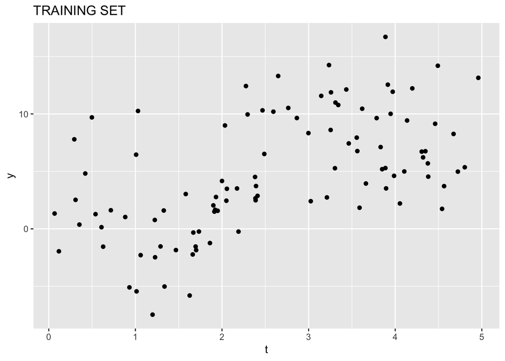

```r
ggplot()+geom_point(data=train, aes(t, y))+ggtitle("TRAINING SET")
```

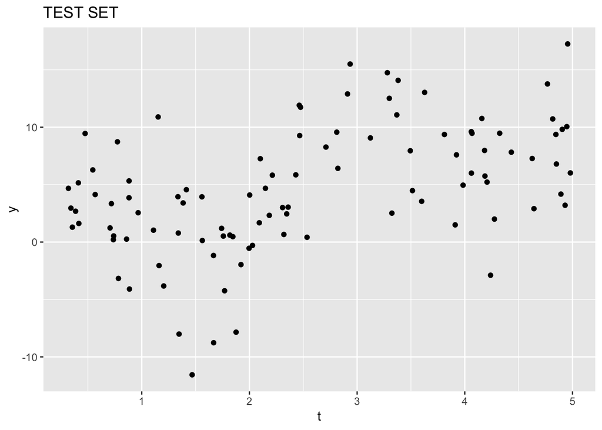

```r
ggplot()+geom_point(data=test, aes(t, y))+ggtitle("TEST SET")
```

QUESTION 2)

Line plot for different polynomial degrees on the training set

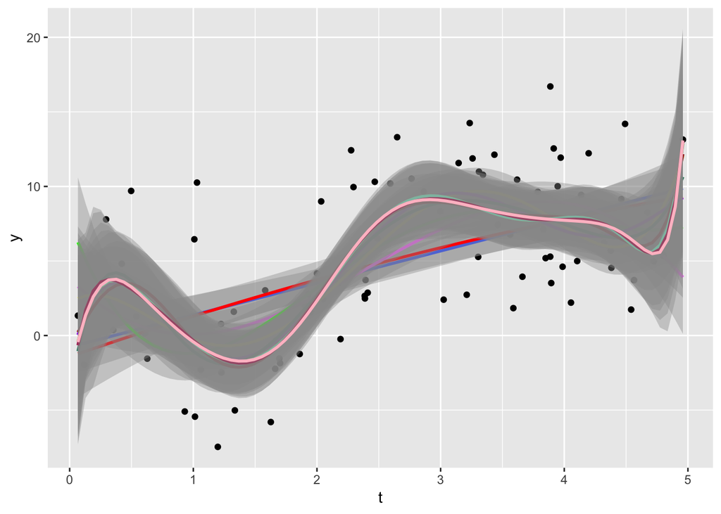

```r
ggplot(data=train,aes(t,y))+
  geom_point()+
  geom_smooth(method="lm")+
  geom_smooth(method="lm",formula=y~poly(x,2),color="red")+
  geom_smooth(method="lm",formula=y~poly(x,3),color="violet")+
  geom_smooth(method="lm",formula=y~poly(x,4),color="green")+
  geom_smooth(method="lm",formula=y~poly(x,5),color="yellow")+
  geom_smooth(method="lm",formula=y~poly(x,6),color="purple")+
  geom_smooth(method="lm",formula=y~poly(x,7),color="aquamarine4")+
  geom_smooth(method="lm",formula=y~poly(x,8),color="brown")+
  geom_smooth(method="lm",formula=y~poly(x,9),color="orange")+
  geom_smooth(method="lm",formula=y~poly(x,10),color="aquamarine")+
  geom_smooth(method="lm",formula=y~poly(x,11),color="maroon")+
  geom_smooth(method="lm",formula=y~poly(x,12),color="pink")
```

Fitting 1 to 12 degree polynomials on training set

```r
#lapply

#lapply(1:12,function(x)=lm(y~poly(t,x),train))

#

first<-lm(y~poly(train$t,1))
train_MSE1 = mean(first$residuals^2)
second<-lm(y~poly(train$t,2))
train_MSE2 = mean(second$residuals^2)
third<-lm(y~poly(train$t,3))
train_MSE3 = mean(third$residuals^2)
fourth<-lm(y~poly(train$t,4))
train_MSE4 = mean(fourth$residuals^2)
fifth<-lm(y~poly(train$t,5))
train_MSE5 = mean(fifth$residuals^2)
sixth<-lm(y~poly(train$t,6))
train_MSE6 = mean(sixth$residuals^2)
seventh<-lm(y~poly(train$t,7))
train_MSE7 = mean(seventh$residuals^2)
eigth<-lm(y~poly(train$t,8))
train_MSE8 = mean(eigth$residuals^2)
ninth<-lm(y~poly(train$t,9))
train_MSE9 = mean(ninth$residuals^2)
tenth<-lm(y~poly(train$t,10))
train_MSE10 = mean(tenth$residuals^2)
eleventh<-lm(y~poly(train$t,11))
train_MSE11 = mean(eleventh$residuals^2)
twelvth<-lm(y~poly(train$t,12))
train_MSE12 = mean(twelvth$residuals^2)
```

Training MSE plot

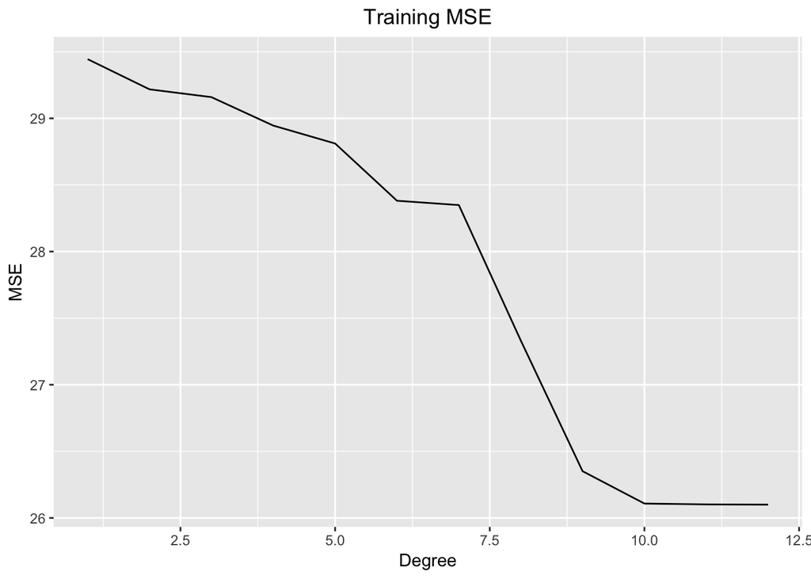

```r
degree<-c(1:12)
MSE<-c(train_MSE1,train_MSE2,train_MSE3,train_MSE4,train_MSE5,train_MSE6,
                         train_MSE7,train_MSE8,train_MSE9,train_MSE10,train_MSE11,train_MSE12)
training_MSE<-data.frame(degree,MSE)

ggplot(training_MSE,aes(degree,MSE))+
  geom_line()+
  labs(title="Training MSE",x="Degree",y="MSE")+
  theme(plot.title = element_text(hjust=0.5))
```

Looking at the Training MSE plot, I would choose the 10th degree polynomial for prediction, as it provides the least amount of MSE. Even though 11 and 12 also provide relatively same amount of MSE, we choose the model which uses the least amount of degrees possible to be more simplistic

QUESTION 3)

In pratice creating a model with 12 degree polynomial to predict the data is overfitting the data, since increasing degrees of polynomial increases the sensitivity to specific training data, thereby increasing MSE. Hence, while the training data shows a continuous decrease in MSE, the test set may not.

QUESTION 4)

Theoretically, the lowest MSE can be the epsilon variance, which in our case is 16, which we derive from the equation y(t) = 2t + 3cos(2t) + C, where C ~ N(0,16). However, we are getting the lowest MSE using the 10th degree polynomial to fit the data, which is giving an MSE of around 26, which is pretty high relative to the lowest theoretical MSE.

QUESTION 5)

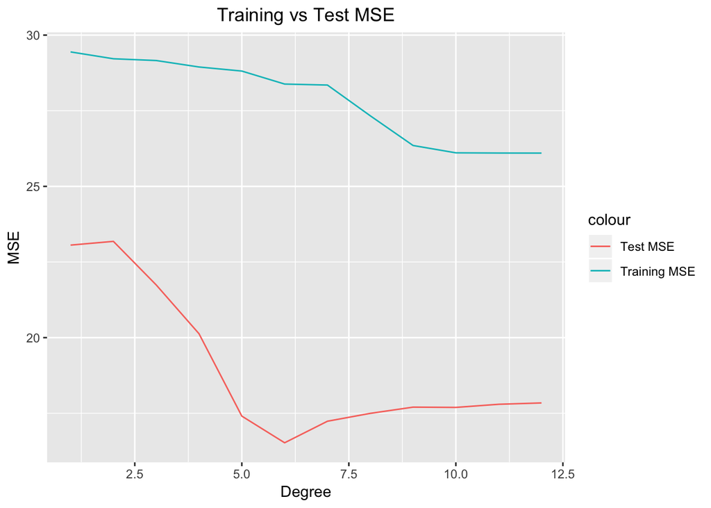

```r
test_error1 <- numeric(12)
for(i in 1:12){
   model1 <- lm(formula=y~poly(t,i), data = train)
   predictMSE<-predict(model1,test)
  test_error1[i] <- mean((test$y-predictMSE)^2)
}


test_error1DF<-data.frame(degree,test_error1)

ggplot() +
  geom_line(aes(x=degree,y=training_MSE$MSE,col="Training MSE"))+
  geom_line(aes(x=degree,y=test_error1DF$test_error1,col="Test MSE"))+
  labs(title="Training vs Test MSE",x="Degree",y="MSE")+
  theme(plot.title = element_text(hjust=0.5))
```

The training MSE does not predict the test MSE very well. While the training model recommended the 10th degree polynomial to be used for predicted, the test MSE shows that the 6th degree polynomial has the lowest MSE. Moreover, the test MSE is quite lower than the training MSE, especially at the 6th degree polynomial, where there the test MSE is extremely low before going back up

QUESTION 6)

```r
lm_model= train(y~t, train, method="lm")
lm_model$results
```

```
##   intercept     RMSE  Rsquared      MAE   RMSESD RsquaredSD     MAESD
## 1      TRUE 4.433435 0.3260462 3.611074 0.421671 0.09532995 0.3799963
```

```r
regressControl1 = trainControl(method="cv",number = 10)

lm_model_cv = train(y~t, train, method="lm", trControl = regressControl1)
lm_model_cv$results
```

```
##   intercept     RMSE  Rsquared      MAE    RMSESD RsquaredSD     MAESD
## 1      TRUE 4.260482 0.3579446 3.548749 0.7850933  0.1367689 0.8377204
```

```r
regressControl = trainControl(method="repeatedcv",number = 10, repeats = 5)

cverror <- numeric(12)
for(i in 1:12){
  f <- bquote(y ~ poly(t, .(i)))
   models <- train(as.formula(f), data = train, trControl=regressControl, method='lm')
  cverror[i] <- (models$results$RMSE)^2
}

cverror
```

```
##  [1] 18.37165 18.57979 16.70956 16.49307 14.70468 15.77893 15.39515
##  [8] 14.95217 15.14025 15.64172 16.75410 17.36436
```

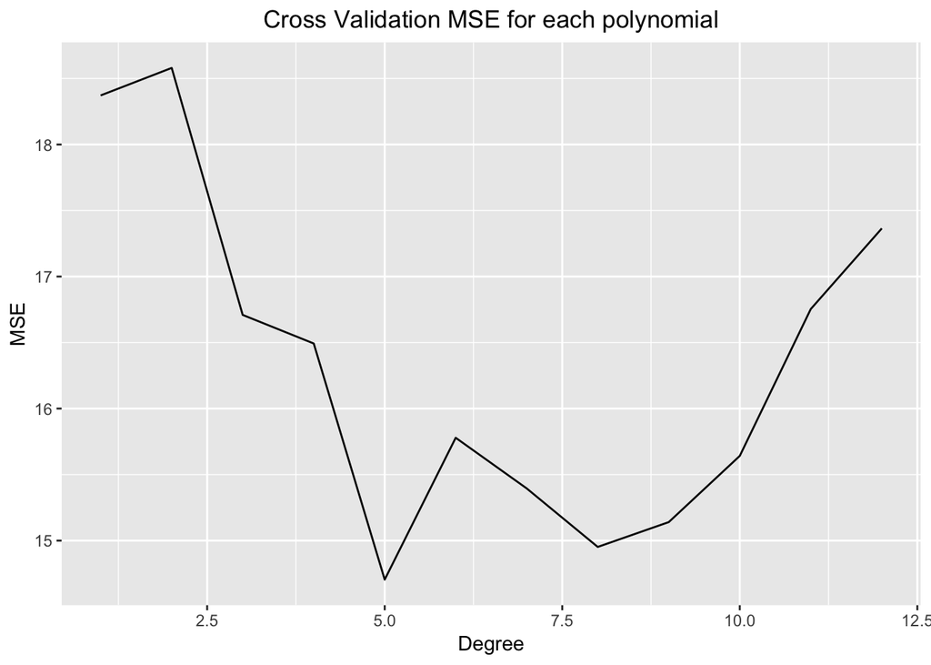

```r
cv_errorDF<-data.frame(degree,cverror)

ggplot(cv_errorDF,aes(degree,cverror))+
  geom_line()+
  labs(title="Cross Validation MSE for each polynomial",x="Degree",y="MSE")+
  theme(plot.title = element_text(hjust=0.5))
```

Based on the minimum MSE criteria, the 5th degree polynomial best predicts new data

QUESTION 7)

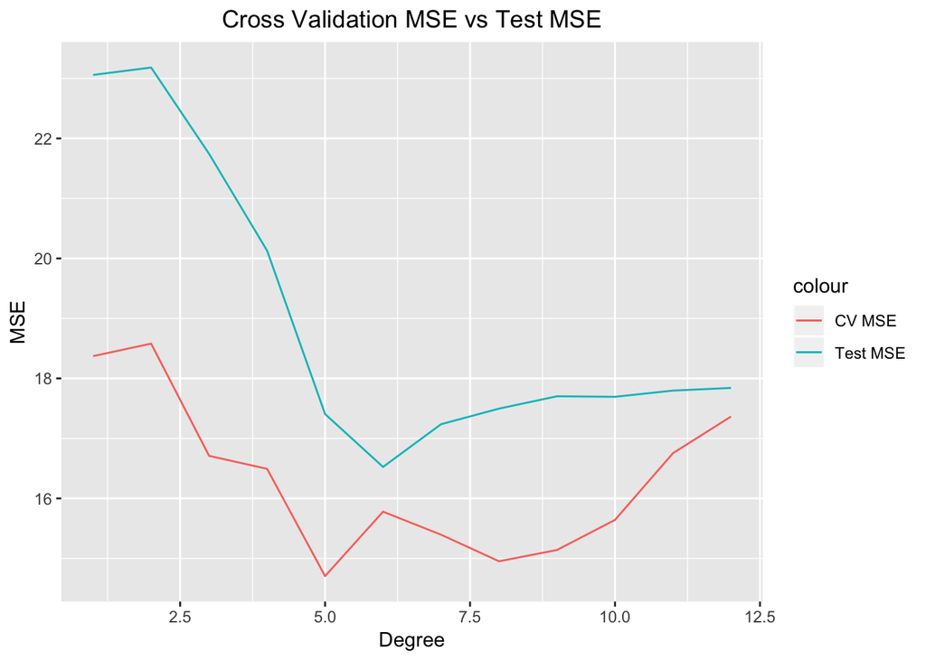

```r
test_error <- numeric(12)
for(i in 1:12){
  f <- bquote(y ~ poly(t, .(i)))
   models <- train(as.formula(f), data = train, trControl=regressControl, method='lm')
   predictMSE<-predict(models,test)
  test_error[i] <- mean((test$y-predictMSE)^2)
}


test_errorDF<-data.frame(degree,test_error)

ggplot()+
  geom_line(aes(test_errorDF$degree,test_errorDF$test_error,col="Test MSE"))+
  geom_line(aes(cv_errorDF$degree,cv_errorDF$cverror,col="CV MSE"))+
  labs(title="Cross Validation MSE vs Test MSE",x="Degree",y="MSE")+
  theme(plot.title = element_text(hjust=0.5))
```

QUESTION 8)

It is because the test MSE using the simple linear regression model from 5) still picks out the best fit for the model, exactly what the Cross Validation model is doing. The only difference between the two is that the Cross Validation model is more robust as it undergoes more repitions, thus providing higher confidence in our prediction. Nevertheless, the prediction of the test MSE still picks out the best MSE trendline from both regression models. The validation test is more of how best the training model can predict the test data.

QUESTION 9)

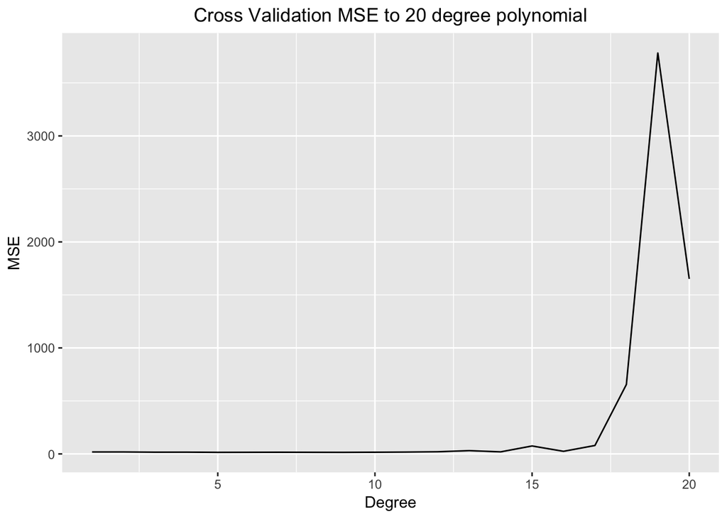

```r
cverror <- numeric(20)
for(i in 1:20){
  f <- bquote(y ~ poly(t, .(i)))
   models <- train(as.formula(f), data = train, trControl=regressControl, method='lm')
  cverror[i] <- (models$results$RMSE)^2
}

degree20<-c(1:20)
cv_errorDF<-data.frame(degree20,cverror)
ggplot(cv_errorDF,aes(degree20,cverror))+
  geom_line()+
  labs(title="Cross Validation MSE to 20 degree polynomial",x="Degree",y="MSE")+
  theme(plot.title = element_text(hjust=0.5))
```

```r
cverror
```

```
##  [1]   18.52310   18.65704   16.41886   16.67758   14.72079   15.20565
##  [7]   15.79721   15.08869   14.67258   15.86616   17.63736   20.44239
## [13]   30.85114   19.42271   75.02378   24.52179   79.63360  654.79360
## [19] 3781.90681 1651.48724
```

We run all the models with different polynomial degrees on the cross validation set. What we will observe is that when the degree of the polynomial is low then the error will be high. This error will decrease as the degree of the polynomial increases as we will tend to get a better fit. However the error will again increase as higher degree polynomials that overfit the training set will be a poor fit for the cross validation set. When we are doing cross validation, the algorithm’s sensitivity to specific training data increases significantly, thus the big jump when we test with very high polynomial degrees.

QUESTION 10)

```r
kerror <- numeric(98)
testMSE<-numeric(98)
for(i in 3:100){
  f <- bquote(y ~ poly(t,5))
  models <- train(as.formula(f), data = train, trControl=trainControl(method="cv",number = i),
  method='lm')
  kerror[i] <- (models$results$RMSE)^2
  predictMSE1<-predict(models,test)
  testMSE[i] <- mean((test$y-predictMSE1)^2)
}
```

[output not shown]

[output cut: 94 more lines]

[output not shown]

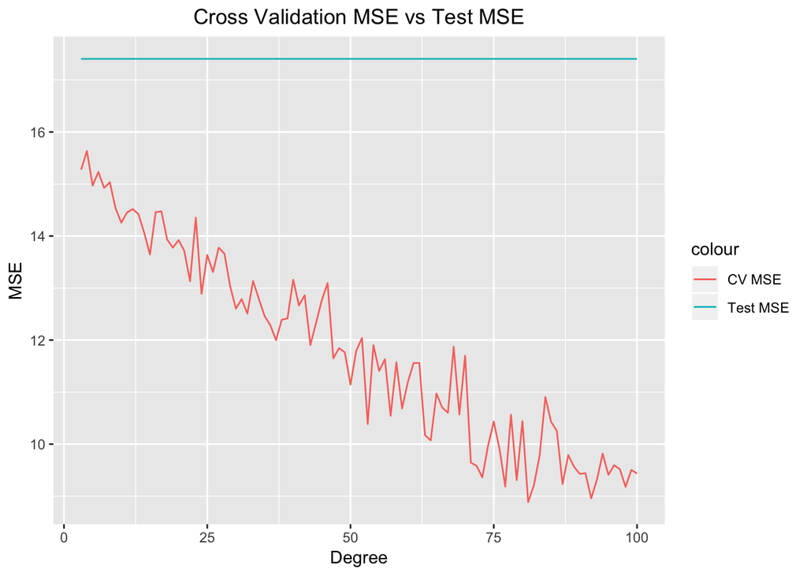

```r
kerror<-kerror[-c(1,2)]
kVals<-c(3:100)
kValsDF<-data.frame(kVals,kerror)

testMSE<-testMSE[-c(1,2)]

ggplot(kValsDF,aes(kVals,kerror))+
  geom_line(aes(kValsDF$kVals,kValsDF$kerror,col="CV MSE"))+
  geom_line(aes(kVals,testMSE,col="Test MSE"))+
  labs(title="Cross Validation MSE vs Test MSE",x="Degree",y="MSE")+
  theme(plot.title = element_text(hjust=0.5))
```

Looking at the CV MSE line in the above plot, we can see that k value and MSE error have a negative correlation. I.e. as we increase the number of groups on which the model will be trained, the MSE error decreases. Nevertheless, we spikes at multiple intervals that do not show complete linearity in the way the MSE changes with respect to k value. Thus, it is safe to say that the cross validation is quite sensitive to the procedure choice of k.

QUESTION 11)